# Various visualizations

Supplement for discussion

Emma Skarstein

9/6/2020

```r
trout_artsobs <- readRDS("../R/output/trout_artsobs.RDS")
trout_survey <- readRDS("../R/output/trout_survey.RDS")
trout_artsobs_df <- readRDS("../R/output/trout_artsobs_df.RDS")
trout_survey_df <- readRDS("../R/output/trout_survey_df.RDS")
```

# 1 Looking at the observations

```r
# Empty map theme
empty_theme_map <- theme(
  plot.background = element_blank(),
  panel.grid.major = element_blank(),
  panel.grid.minor = element_blank(),
  panel.border = element_blank(),
  panel.background = element_blank(),
  axis.line = element_blank(),
  axis.ticks = element_blank(),
  axis.title.x = element_blank(),
  axis.title.y = element_blank(),
  axis.text = element_blank()
)
empty_theme <- theme(
  plot.background = element_blank(),
  panel.grid.major = element_blank(),
  panel.grid.minor = element_blank(),
  panel.border = element_blank(),
  panel.background = element_blank(),
  axis.text.x = element_blank(),
  axis.title.x = element_blank()
)

# Setting up color palette
trutta_colors <- fish(n = 20, option = "Salmo_trutta")
#fishualize(option = "Salmo_trutta")
```

## 1.1 Observation map

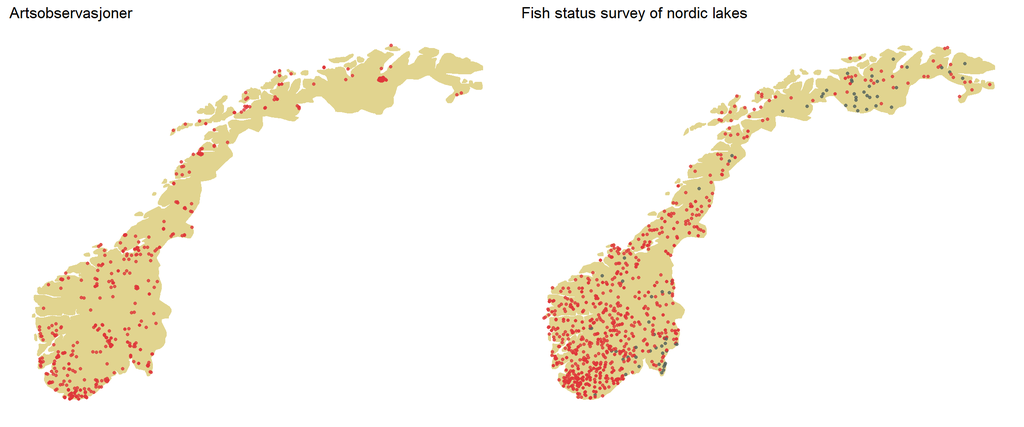

```r
norway <- ggplot2::map_data("world", region = "Norway(?!:Svalbard)")
norway <- dplyr::setdiff(norway, filter(norway, subregion == "Jan Mayen"))
p1 <- ggplot(data.frame(trout_artsobs)) +
  geom_polygon(data = norway, aes(long, lat, group = group),
                 color=trutta_colors[11], fill = trutta_colors[11]) +
  geom_point(aes(x = decimalLongitude, y = decimalLatitude),
               color = trutta_colors[4], alpha = 0.8, size = 1) +
  empty_theme_map +
  ggtitle("Artsobservasjoner")

p2 <- ggplot(data.frame(trout_survey)) +
  geom_polygon(data = norway, aes(long, lat, group = group),
                 color=trutta_colors[11], fill = trutta_colors[11]) +
  geom_point(aes(x = decimalLongitude, y = decimalLatitude, color = occurrenceStatus), alpha = 0.8, size = 1) +
  scale_color_manual(values=c(trutta_colors[15],trutta_colors[4])) +
  theme(legend.position = "none") +
  empty_theme_map +
  ggtitle("Fish status survey of nordic lakes")

ggarrange(p1, p2)
```

Above, I have plotted all the observations for both data sets. Note that the “Fish status survey of nordic lakes” data set is presence/absence, presences are in red in both plots, while absences are in grey when reported.

To get a better impression of observation density across the map, we look at a hexagon map.

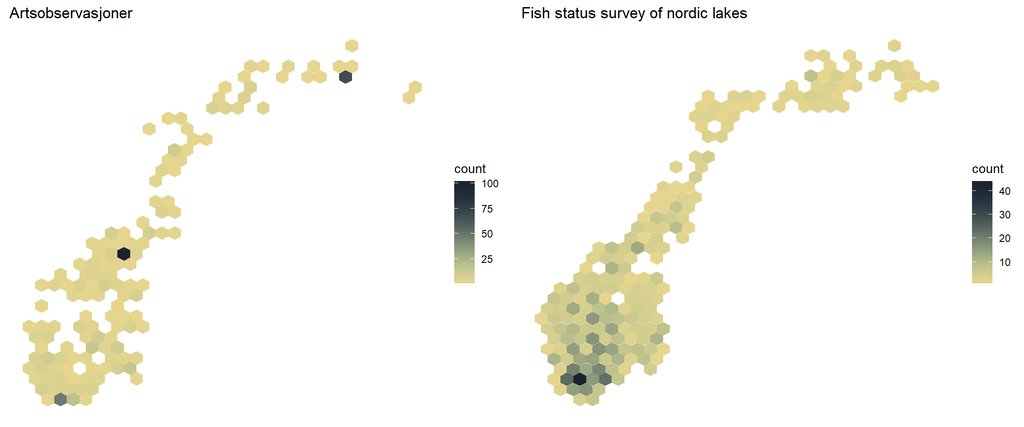

```r
p1 <- ggplot(data.frame(trout_artsobs), aes(x = decimalLongitude, y = decimalLatitude)) +
  #geom_polygon(data = norway, aes(long, lat, group = group)) +
  geom_hex() +
  empty_theme_map +
  scale_fill_fish(option = "Salmo_trutta", begin = 0.52, end = 0.9, direction = 1)+
  ggtitle("Artsobservasjoner")

p2 <- ggplot(data.frame(trout_survey), aes(x = decimalLongitude, y = decimalLatitude)) +
  #geom_polygon(data = norway, aes(long, lat, group = group)) +
  geom_hex() +
  empty_theme_map +
  scale_fill_fish(option = "Salmo_trutta", begin = 0.52, end = 0.9, direction = 1)+
  ggtitle("Fish status survey of nordic lakes")

ggarrange(p1, p2)
```

## 1.2 Number of observations per year

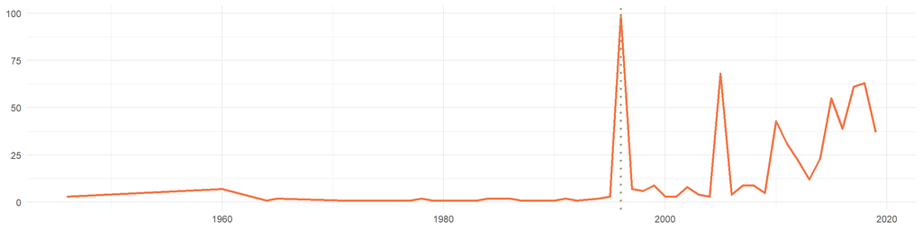

```r
time_counts <- count(trout_artsobs_df, year)

ggplot(time_counts, aes(x = year, y = n)) +
  geom_line(size = 1, color = trutta_colors[7]) +
  theme_minimal() +
  theme(axis.title = element_blank()) +
  geom_vline(xintercept = 1996, linetype = "dotted", color = trutta_colors[13], size = 1)
```

Number of observations per year for the Artsobservasjoner data. The dotted vertical line is in 1996, which is the year all the survey observations are made.

## 1.3 Number of observations per square kilometer by county

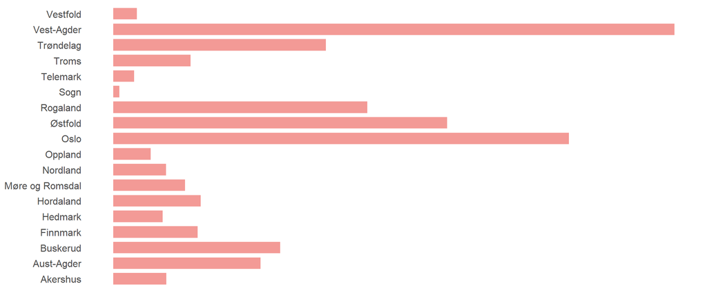

```r
fylke_areal <- c(4918, 9155, 14912, 48631, 27398, 15438, 14469, 38472, 25192, 454, 4187, 9377, 18623, 15298, 24879, 41898, 7279, 2225)

trout_artsobs_df$county.y <- trout_artsobs_df$county.y %>% recode("Sør-Trøndelag" = "Trøndelag", "Nord-Trøndelag" = "Trøndelag")
dense_fylke <- cbind(count(trout_artsobs_df, vars = county.y), fylke_areal) %>% mutate(obs_per_area = n/fylke_areal)

ggplot(dense_fylke, aes(x = vars, y = obs_per_area)) +
  geom_bar(stat = "identity", color=trutta_colors[2], fill=trutta_colors[2], width = 0.7) +
  #geom_text(aes(label = obs_in_county), hjust = -0.5, color="black", size=4) +
  coord_flip() +
 # ylab("Observations per km^2") +
  theme_minimal() +
  theme(text = element_text(size = 15),
        axis.title.y = element_blank())+
  empty_theme
```

Number of observations per square km, by county, in the Artsobservasjoner data.

# 2 Explanatory variables

The possible explanatory variables are

- `area_km2`: the area of the lake, in square kilometers
- `perimeter_m`: the perimeter of the lake, in meters
- `distance_to_road`: the distance to the closest road
- `eurolst_bio10`: average temperature of the warmest annual quarter, in degrees celcius multiplied by 10
- `catchment_area_km2`: the catchment area of the lake, in square kilometers
- `SCI`: shoreline complexity index
- `HFP`: human footprint index

What is intersting to look at here? Distribution of variables in space, but also distribution of the variables themselves.

```r
Covariates <- readRDS("../R/output/Covariates.RDS")
Cov_long <- gather(data.frame(Covariates), key = variable, value = value, area_km2:log_catchment)
```

## 2.1 Explanatory variables on a map

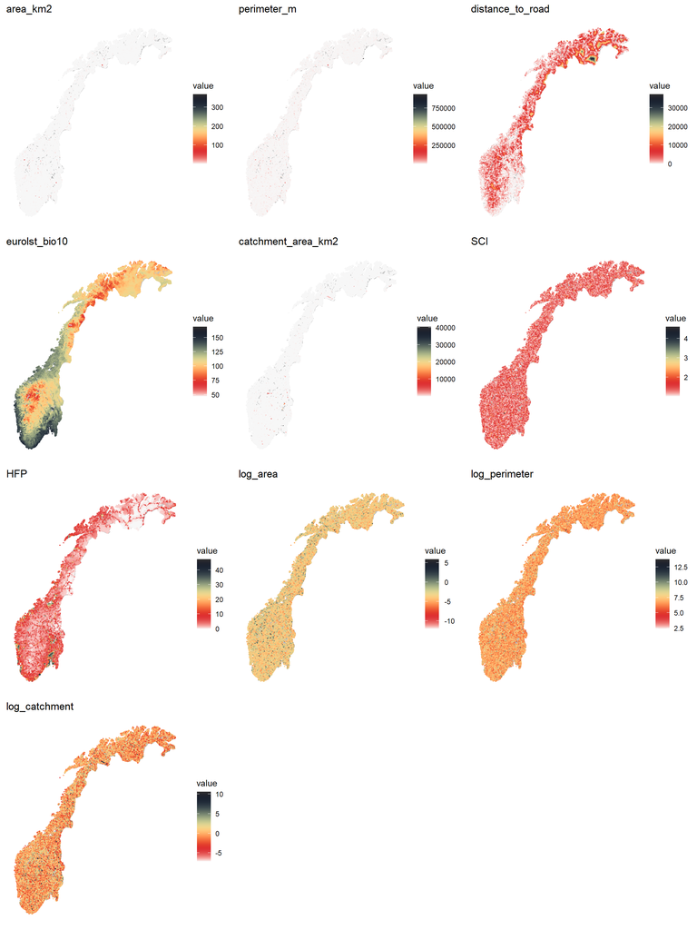

```r
plot_exp_var <- function(var){
  ggplot(Cov_long %>% dplyr::select(variable, value, decimalLatitude, decimalLongitude) %>%
                filter(variable==var)) +
    geom_polygon(data = norway, aes(long, lat, group = group),
                 color = "grey", fill = "grey") +
    geom_point(aes(x = decimalLongitude, y = decimalLatitude, color = value),
             alpha = 0.8, size = 0.3) +
    scale_color_fish(option = "Salmo_trutta") +
    #scale_color_gradient(low = trutta_colors[], high = "darkblue")
    empty_theme_map +
    ggtitle(var)
}
Cov_names <- unique(Cov_long$variable)
var_plots <- lapply(Cov_names, plot_exp_var)

ggarrange(plotlist = var_plots, nrow = 4, ncol = 3)
```

## 2.2 Explanatory variables summary

```r
descr(data.frame(Covariates)[,4:13], stats = "fivenum", transpose = TRUE)
```

Descriptive Statistics

|  | Min | Q1 | Median | Q3 | Max |
| --- | --- | --- | --- | --- | --- |
| area_km2 | 0.00 | 0.01 | 0.02 | 0.06 | 369.47 |
| catchment_area_km2 | 0.00 | 0.23 | 0.76 | 2.86 | 40501.43 |
| distance_to_road | 0.00 | 782.00 | 2402.00 | 5337.00 | 37263.00 |
| eurolst_bio10 | 47.33 | 102.37 | 109.12 | 123.02 | 168.69 |
| HFP | 0.00 | 1.25 | 2.36 | 5.00 | 47.28 |
| log_area | -12.00 | -4.39 | -3.77 | -2.82 | 5.91 |
| log_catchment | -7.13 | -1.46 | -0.28 | 1.05 | 10.61 |
| log_perimeter | 2.40 | 6.30 | 6.71 | 7.29 | 13.75 |
| perimeter_m | 11.00 | 547.00 | 823.00 | 1459.00 | 937991.00 |
| SCI | 1.01 | 1.19 | 1.32 | 1.54 | 4.61 |

## 2.3 Explanatory variables histograms

To display sort of the same info as the table.

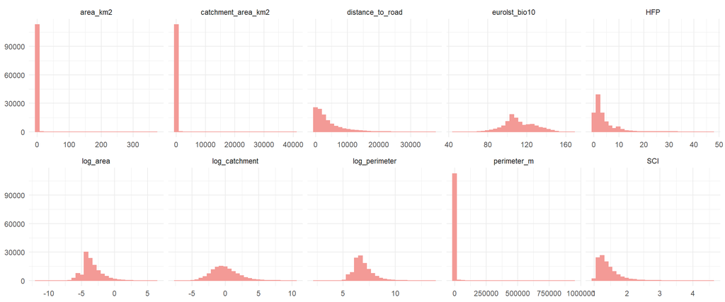

```r
ggplot(Cov_long, aes(x = value)) +
    geom_histogram(fill = trutta_colors[2], color = trutta_colors[2]) +
      facet_wrap(~variable, scales = 'free_x', nrow = 2) +
  theme_minimal() +
  theme(axis.title = element_blank())
```

# 3 Exploring model output

Spatial fields, predictions, comparing preformance of the four models

```r
Projection <- CRS("+proj=longlat +ellps=WGS84")
norwayfill <- map("world", "norway", fill=TRUE, plot=FALSE,
                  ylim=c(58,72), xlim=c(4,32))
IDs <- sapply(strsplit(norwayfill$names, ":"), function(x) x[1])
norway.poly <- map2SpatialPolygons(norwayfill, IDs = IDs,
                                   proj4string = Projection)
Meshpars <- list(cutoff=0.08, max.edge=c(1, 3), offset=c(1,1))
Mesh <- MakeSpatialRegion(data=NULL, bdry=norway.poly, meshpars=Meshpars,
                          proj = Projection)
source("../R/Model_visualization_functions.R")
```

## 3.1 Comparing different models

```r
res <- readRDS("../R/output/cv_output_4mods.RDS")

dic_values <- matrix(unlist(res), ncol = 5)
av_dic <- rowMeans(dic_values)
```

(please ignore the actual numbers, I do not trust them)

1 spatial field

2 spatial fields

**Env. covariates**

6800.9047929

```
860.2044
```

**Env. + effort** **covariates**

479.2709594

824.1562596

Above: Result of block cross-validation, comparing four different models. The numbers are the marginal deviance for each model.

## 3.2 Looking at final model

```r
model_final <- readRDS("../R/output/model_final_1.RDS")

summary(model_final$model)
```

```
##
## Call:
##    c("INLA::inla(formula = Formula, family = c(\"poisson\", \"binomial\"),
##    ", " data = INLA::inla.stack.data(stck), E =
##    INLA::inla.stack.data(stck)$e, ", " offset = offset.formula, Ntrials =
##    INLA::inla.stack.data(stck)$Ntrials, ", " verbose = verbose,
##    control.compute = list(waic = waic, dic = dic), ", " control.predictor
##    = list(A = INLA::inla.stack.A(stck), link = NULL, ", " compute = TRUE),
##    control.family = list(list(link = \"log\"), ", " list(link =
##    \"cloglog\")), control.results = list(return.marginals.random = FALSE,
##    ", " return.marginals.predictor = FALSE), control.fixed =
##    control.fixed)" )
## Time used:
##     Pre = 13.2, Running = 1263, Post = 2.05, Total = 1278
## Fixed effects:
##                    mean     sd 0.025quant 0.5quant 0.975quant   mode kld
## int.survey        6.240 10.196    -20.415    6.632     27.383  5.939   0
## int.artsobs       5.448 11.794    -23.716    6.028     29.526  5.395   0
## decimalLongitude -0.194  0.114     -0.447   -0.183     -0.002 -0.156   0
## decimalLatitude  -0.051  0.030     -0.119   -0.047     -0.001 -0.041   0
## log_area          0.015  0.021     -0.025    0.015      0.055  0.015   0
## perimeter_m       0.000  0.000      0.000    0.000      0.000  0.000   0
## eurolst_bio10    -0.002  0.004     -0.009   -0.002      0.006 -0.002   0
## SCI               0.029  0.114     -0.197    0.029      0.252  0.031   0
## distance_to_road  0.000  0.000      0.000    0.000      0.000  0.000   0
## HFP               0.000  0.005     -0.010    0.000      0.010  0.000   0
##
## Random effects:
##   Name     Model
##     shared_field SPDE2 model
##    bias_field SPDE2 model
##
## Model hyperparameters:
##                          mean    sd 0.025quant 0.5quant 0.975quant  mode
## Theta1 for shared_field  1.16 0.287      0.608     1.16       1.74  1.14
## Theta2 for shared_field -2.87 0.759     -4.442    -2.83      -1.45 -2.72
## Theta1 for bias_field    1.39 0.321      0.830     1.37       2.08  1.27
## Theta2 for bias_field   -2.50 0.713     -4.108    -2.41      -1.37 -2.04
##
## Expected number of effective parameters(stdev): 28.37(3.57)
## Number of equivalent replicates : 130.97
##
## Marginal log-Likelihood:  -961.96
## Posterior marginals for the linear predictor and
##  the fitted values are computed
```

We can plot the predictions (not shown) as well as the spatial field means and standard deviations:

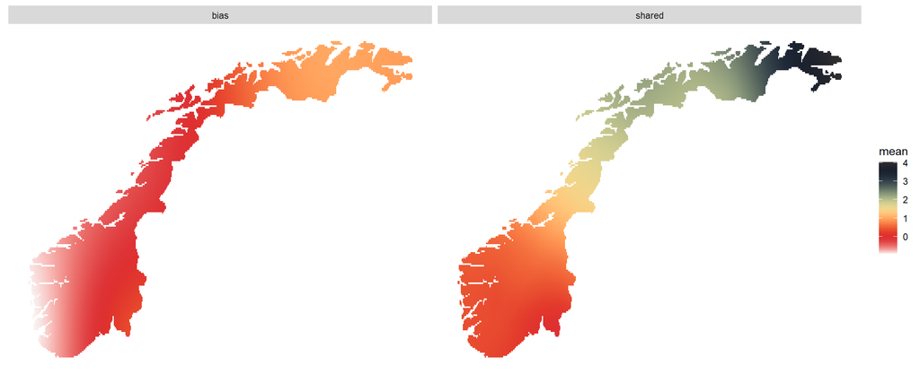

```r
spat_fields_df <- proj_random_field(model_final$model, sp_polygon = norway.poly, mesh = Mesh$mesh)

ggplot(spat_fields_df) +
  geom_polygon(data = norway, aes(long, lat, group = group),
               color="white", fill = "white") +
    geom_raster(aes(x = decimalLongitude, y = decimalLatitude, fill = mean)) +
  scale_fill_fish(option = "Salmo_trutta") +
  empty_theme_map +
  facet_wrap(~ field)
```

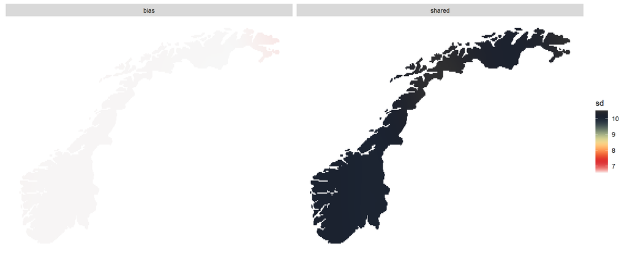

```r
ggplot(spat_fields_df) +
  geom_polygon(data = norway, aes(long, lat, group = group),
               color="white", fill = "white") +
    geom_raster(aes(x = decimalLongitude, y = decimalLatitude, fill = sd)) +
  scale_fill_fish(option = "Salmo_trutta") +
  empty_theme_map +
  facet_wrap(~ field)
```